# How to forecast econometric and financial time-series with genetic Dynamic Bayesian Networks and Associative Rules

in this article, we will be forecasting **CPI** ( Consumer Price Index )

LloydL

2020 01 15

```r
# this is the key function extending bnlearn to perform dynamic bayesian networks similar to
# the layering feature found in bnstruct

blackList = function( nn=names(xx)[ss] ){
cm = t(  combn( nn, m=2 )  )                # nn has to be in order by lag number    transpose so combos are by row
blk.lst = matrix( ' ', ncol=2, nrow=10*length(nn) )
colnames( blk.lst ) = c( 'from', 'to' )

blk.lst [ 1:length(nn), 'from' ] = 'response'       # response is at lag 0 so it cannot go to all other nodes
blk.lst [ 1:length(nn) , 'to' ] = nn
blk.lst [ (length(nn)+1):( length(nn) + nrow( cm ) ), c( 'from', 'to' ) ] =  cm    # by rows now
L = ( length(nn) + nrow( cm ) )         # row L is already is use   serves as new baseline
for( ii in 1:4 ) {
pp = paste( '_L', ii, sep = '' )
lev1 = str_detect( cm[ , 1 ],  pp  )
lev2 = str_detect( cm[ , 2 ],  pp )
mm = lev2 & lev1                   # these are matches of lev1 and lev2  both must be true  index is the same as cm
M = sum( ifelse( mm==T, 1,  0 )  )
if( M  > 0 ){
     blk.lst[ (L+1):( L + M ), c( 'to', 'from' ) ]  = cm[ mm, ]
     L = L + M
  } # end if
}  # end for ii

return( blk.lst[ 1:L,  ] )

} # end of function

### this display the strength.plot of the dynamic bayesian network

showStrength = function( xx=xx, response=response, response.name=response.name, df=df, sampleSize=sampleSize, db=db , font.size = 75, titleSuffix = ' chg % in CPI (consumer price index) y/y' ){
dev.new()    # active graphics device for strength.plot fontsize work-around
dev.new()
dev.lst = dev.list()
dev.set( which = dev.lst[[1]] )
#   par(ask=T )
fc = rep( 0, nrow( df ) )   # stores forecasts which is forecast[3]  because xx.test has 2 rows
nn = colnames( xx )
for( ii in 1:nrow(df) ){
ss = unlist( df[ ii, 1:sampleSize ] )
xxx = as.data.frame( cbind( response=response,  xx[ ,  ss ]  ) )
names( xxx ) = c( 'response', nn[ss]  )
blk.lst = blackList( colnames(xx)[ ss ] )
res  = hc( xxx, blacklist=blk.lst, restart = 4, perturb = 6, max.iter = 600, maxp = 3, optimized = T )
strength = arc.strength( x=res, data=xxx )
res.fit = bn.fit( x=res, data=xxx, cluster = NULL, method = "mle" )
rr  = residuals( res.fit )[[ 'response' ]]
err = median( abs( rr ) )
pp = parents( x=res.fit, node='response' )
forecast = predBN( nn = nn[ ss ], bn.fit = res.fit, db = db )   # a vector
fwd.error = abs( response.test[ 1:2 ] - forecast[ 1:2 ] )
fc[ ii ] = forecast[ 3 ]
bn.score = bnlearn::score( res , xxx, type = "bge" )
wh = which( strength[ , 'to' ] == 'response' )
arcStr = sum( strength[ wh, 'strength' ] );
subText = paste(  'fwd errors ( ', round( fwd.error[1] , 3 ), ' , ', round( fwd.error[2] , 3 ), ' )  ; with mad error ' , round( err, 2 ),
' ; bayes.net.score ', round( bn.score, 1), '  ;  response total arc.strength ',  round(arcStr,1) ,  sep='' )
mainText = paste( paste( 'Dynamic Bayesian Network for: ' , response.name ) , '\n', ' forecast ===> ',  round( forecast[3] , 3 ), '  ',  titleSuffix , sep='' );
# all this to accommodate a bug in plot.strength (fontsize)
dev.set( which=dev.lst[[2]] )
g1 = strength.plot( x=res, strength = strength, layout = 'dot', shape = "circle" , main = mainText  , sub = subText  )
dev.set( which = dev.lst[[ 1 ]] )
x <- layoutGraph( x = g1 )
nodeRenderInfo( x ) = list(  fontsize = font.size  )
renderGraph( x )

}  # end of for ii

return( paste( 'median forecast: ', median ( fc ) ) )
} # end of fun


#this filters out weaker models by evaluating goodness of fit #(median absolute residuals over the ENTIRE SERIES )
# and network connectivity ( total abs (correlations) )
# take note concerning xx.test and xx.response, they are not
# implemented as out-of-sample yet
# due to a presentation and programming problem .)

# parBN.Filter  is a parallel filter that converts the list results of corConn also parallel
# into a data.frame.
parBN.Filter = function( X = parBN, xx=xx, response=response, totalConn = 8,   acceptableError = 25000, sampleSize = sampleSize, db=cpiDb  ) {
df.bn = rep( 0, ncol= 16 )
if( is.null( X )|| length( X$ss ) == 0 || X$ss == rep( 0, length( X$ss ) ) ) return( df.bn )
xxx = xx[ , X$ss ]
nn = colnames(xxx)
blk.lst = blackList( nn )
xxx = as.data.frame( cbind( response, xxx ) )
colnames( xxx ) = c( 'response', nn )

res  = hc( xxx , blacklist=blk.lst, restart = 4, perturb = 6, max.iter = 200, maxp = 3, optimized = T )
res.fit = bn.fit( x=res, data=xxx, cluster = NULL, method = "mle" )
rr  = residuals( res.fit )[[ 'response' ]]
err = median( abs( rr ) )

forecast = predBN( nn = nn, bn.fit = res.fit, db = db )   # a vector
fwd.error = abs( response.test[ 1:2 ] - forecast[ 1:2 ] )

# compute local arc strength centered on the response
strength = arc.strength( x=res , data=xxx )
wh = which( strength[ , 'to' ] == 'response' )
arcStr = sum( strength[ wh, 'strength' ] );

forecast = predBN( nn = nn , bn.fit = res.fit, db = db )   # a vector
fwd.error = abs( response.test[ 1:2 ] - forecast[ 1:2 ] )

bn.score = bnlearn::score( res , xxx, type = "bge" )

# if(  X$totalRock >= totalConn && err <= acceptableError ){
        df.bn[  1:sampleSize ] = X$ss
        X$fwd.error = fwd.error[1:2]
        X$forecast = forecast[ 3 ]
        X$bnScore = bn.score
        X$arcStr = arcStr   # local arc strength
        X$parentCount = length( parents( x=res.fit, node='response' ) )
         L = length(X$ss)
       X = unlist( X )
         df.bn[ (L+1):(L+8) ]  = X[(L+1):(L+8) ]
#       } # endif

return( df.bn )   # filtered results
}  # end of fun

corConn = function( response, xx, sampleSize = 8, totalCor = 12,   x=CM  ){
ss = sort( x  )                # sample( 1:ncol(xx), sampleSize )
nn = colnames( xx )[ ss ]
xxx = cbind( response = response, xx[ , ss ] )
xxx = as.data.frame( xxx )
names( xxx ) = c( 'response', nn )
ddp = dedup( data = xxx, threshold = 0.95 , debug = F  )  # collinearity, it's murder !
if( ncol( ddp ) < length( x ) ) return( list( ss = rep(0,length(ss)), totalRock = 0, response.cor = 0 ) )

blk.lst = blackList( nn )
rocker = abs( cor( xxx ) )
# acquire the response corrs (most important for forecasting response )
response.cor = ifelse( 0.33 <= rocker[ 'response' , ] & rocker[ 'response' , ]  <= 0.95, 1 , 0 )
if( sum( response.cor ) < 2 )    return( list( ss = rep(0,length(ss)), totalRock = 0, response.cor = 0 )  )
colnames( rocker ) = c( 'response', nn )    # restore the name space again
rownames( rocker ) = c( 'response', nn )    # restore the name space again
rocker[ as.matrix( rocker ) ] = 0

ut = upper.tri( rock, diag = T )
rocker[ ut ] = 0     # from corresponds to rows; to corresponds to  columns
rocker = as.vector( rocker   )
rocker = rocker[ rocker != 0 & !is.na( rocker ) ]
qq = quantile( rocker, 0.1 )
rock =   ifelse( ( max( qq , 0.2 ) < rocker  & rocker  < 0.92 ) , 1 , 0  )   # count the number of probable arcs
totalRock = sum( rock )
if(  totalCor <= totalRock ) {
      return( list( ss = ss, totalRock = totalRock, response.cor = sum( response.cor )  ) )
  }
else return( list( ss = rep(0,length(ss)), totalRock = 0, response.cor = 0 ) )
# end if

} # end fun

### this creates the forecasts, the first two are for partial validation and the third is the actual forecast
predBN = function( nn = nn, bn.fit, db = cpiDb ){
ss = strsplit(  nn, '_L' )
nm = rep( '  ' , length(ss) )
for( ii in 1:length( ss ) ) nm[ ii ] = as.character( ss[[ ii ]][1] )
lag.names<-paste( '_L', 1:4, sep='')
colNames = outer( nm, lag.names, paste, sep='' );
colNames =  sub( pattern='  ', x=colNames, replacement=' ' )
xs = db[ , nm ]
em = embed( as.matrix( xs ), 4 )
colnames( em ) = as.vector( colNames )
dd = as.data.frame( tail( em, 3 ) )  # the most recent relevant rows   1 true forecast and 2 validations
predictions.ahead = predict( bn.fit, node = "response", dd, method = "parents")
forecast = predictions.ahead[ 1:length(predictions.ahead) ]
return( forecast )

}  # end of fun

corNet = function( xx, corThresh, font.size = 75  ) {
nn = colnames( xx )
cc = abs( cor( xx  )  )
L = nrow( cc )
diag( cc ) = 0
cc = as.vector( cc )
qq = quantile( cc , corThresh )
cc = ifelse( cc > qq , 1, 0 )
cc = matrix( cc, ncol=L , nrow=L )
rownames( cc ) =  colnames( cc ) = nn
cr = abs( cor( response, xx ) )
cr = ifelse( cr <= ( corThresh * 0.92 ), 1, 0 )
cc[ 1, ] = cc[ , 1 ] = cr
g1 <- graphAM( adjMat = cc )
x <- layoutGraph(  g1 )
nodeRenderInfo( x ) = list(  fontsize = font.size , fillcol='blue' )
renderGraph(x)
} # end of fun

GeneFreq = function( df = df.bn, xx, sampleSize = 8 ){
mn = min( 1000, nrow(df) )
pop = matrix( 0, nrow = mn , ncol=ncol(xx) )
for( ii in 1:mn ){
      ss = unlist( df[ ii, 1:sampleSize ] )
      ss = ss[ ss>0 ]
      pop[ ii, ss ] = ss;
}

z<-  ifelse( pop > 0, 1,  0 )
chrom.rowCount = dim(z)[1]
total.colCount=dim( z )[2]  # includes lags as separate vars
geneCount = apply( z, 2, sum )
# take the top forty frequencies and corresponding names
gc.srt = sort( geneCount, index.return=TRUE, decreasing=T );
mm = min( 20, length(gc.srt$x) );
geneCount =  gc.srt$x[ 1:mm ];

ColNames = colnames(xx)[  gc.srt$ix[1:mm] ];
plot( x=1:length(geneCount), y=geneCount, type='h', ann=F, lwd=1.5  )
title( main =  'Gene Frequencies Bar Chart',
        xlab='Genes by Column Number', ylab='Gene Frequency'  )
points( x=1:length(geneCount), y=geneCount, pch=16, cex=0.75, col='purple2' );
qq=quantile( geneCount, 0.1 )
text( x=1:length(geneCount)-0.4,  y=rep( qq, length(geneCount) ), labels=ColNames , srt=90,  cex = 1.25, col='red', adj=c(0, 0.5)   )
mtext(text=as.character(geneCount), side = 3, line = 0, outer = FALSE,
           at = 1:mm , cex = 0.65 )            # pos=1,

return( gc.srt );

}  # end of fun

Mutate = function( df.bn = df.bn[ , 1:sampleSize ], mutationPct =  0.20, columnSpace = xx, response )  {
popSize = nrow( df.bn )
chromosomeLength = ncol( df.bn )
# mutate a pair of genes of a randomly selected chromosome
# one on goes off (->0), one off goes on (0->integer in nullSpace)
# select at random mutationPct of population
mutationPopSize = ceiling( popSize * mutationPct  )
chromosomes = matrix ( 0, ncol = chromosomeLength, nrow = mutationPopSize )
for( k in 1:mutationPopSize ) {      # begin for mutation loop
       chromosomes[ k,  ] = unlist( df.bn[ sample( x=1:popSize, size=1, replace=F ) , ] );
       nullSpace = setdiff( 1:ncol( xx ), chromosomes[ k, ] )
       on.gene.loc =  sample( x = 1:chromosomeLength , size=1 )  # location in chromosomes
       repl.gene =  sample( x = nullSpace, size=1 )  # column in xx not already in chromosomes
       chromosomes[ k, on.gene.loc ] = repl.gene
       chromosomes[ k , ] = sort( chromosomes[ k , ] )
}      # end for mutation loop

return( chromosomes  );

}  # end of function

crossOver  = function ( df = df.bn[ , 1:sampleSize ], crossOverPct =  0.20  ) {
popSize = nrow( df )
chromosomeLength = ncol( df )

childrenPopSize = 2 * ceiling( popSize * crossOverPct  )
chromosomes  = matrix( 0, nrow = childrenPopSize, ncol = chromosomeLength )

for (  child in  seq( 1, childrenPopSize-1 , by = 2 )  ) {
    parents = sample( 1:nrow( df ), size=2, replace=F )
   ss = sample( 1:nrow( df ), size=2, replace=F )
    p1  =  df [ ss[1] , ];
    p2  =  df [ ss[2] , ];
    # swap one gene on each chromosome
    p1.swap.loc = sample( 1:length(p1), 1 )
    p2.swap.loc = sample( 1:length(p2), 1 )
    store.val = p2[ p2.swap.loc ]
    p2[ p2.swap.loc ] = p1[ p1.swap.loc ]
    p1[ p1.swap.loc ] =  store.val
    chromosomes[ child,  ] = unlist( p1 )
    ch = child+1
    chromosomes[ ch,  ] = unlist( p2  )
} # end breeding period for this generation

chromosomes = chromosomes[ rowSums ( x = chromosomes ) > 0, ]

return( chromosomes  );

}  # end of function
```

Abstract: This article concerns genetic dynamic bayesian networks. The genetic algorithm randomly samples integers which correspond to column numbers in the dynamic data.frame. These random samples are all of size 8. Each column corresponds to a time-series that hopefully has some bearing on the future behavior of the response variable, CPI. Each bayesian network so generated will be evaluated according to its predictive accuracy on the test data, the bayesian score for the network as a whole and local arc strength for the parents of the response. The genetic algorithm will mutate and cross-fertilize the best 1000 networks consisting of 8 predictive nodes and a response one gene at a time. The posterior density is multivariate normal with linear means. This article includes the data and software. I have completely illustrated all concepts. In this brief example, we will be trying to model and forecast the economy of the United States. These forecasts are for demonstration purposes only. Past behavior is no sure or certain predictor of future behavior.

Keywords: Forecasting, econometrics, financial forecasting, dynamic modeling, bayesian networks, time-series analysis, machine learning, pattern recognition, models of US economy, genetic algorithms, associative rules.

*This software and data are free and comes with ABSOLUTELY NO WARRANTY. You are welcome to modify or redistribute it under the terms of the GNU General Public License (License GPL (>= 2)). For more information about these matters, see http://www.gnu.org/copyleft/gpl.html.*

cpiDb is a data.frame that I created from 244 econometric time series from “fred” ( US Federal Reserve Database where all time-series dates run from 1991-01-01 to the present )  
here is a portion of that data.frame. I imputed all missing values with bayesian methods.

example from cpiDb

|  | Unemployment.Rate | CPI | Payroll.Employment | Aaa.Corp.Bond.Yld | Baa.Corp.Bond.Yld |
| --- | --- | --- | --- | --- | --- |
| 1991-01-01 | 6.4 | 5.64706 | -0.12912 | 9.04 | 10.45 |
| 1991-02-01 | 6.6 | 5.31250 | -0.63965 | 8.83 | 10.07 |
| 1991-03-01 | 6.8 | 4.82115 | -0.97406 | 8.93 | 10.09 |
| 1991-04-01 | 6.7 | 4.80993 | -1.20432 | 8.86 | 9.94 |
| 1991-05-01 | 6.9 | 5.03486 | -1.44575 | 8.86 | 9.86 |
| 1991-06-01 | 6.9 | 4.69592 | -1.38362 | 9.01 | 9.96 |
| 1991-07-01 | 6.8 | 4.36782 | -1.39496 | 9.00 | 9.89 |
| 1991-08-01 | 6.9 | 3.79939 | -1.18960 | 8.75 | 9.65 |
| 1991-09-01 | 6.9 | 3.39623 | -1.07925 | 8.61 | 9.51 |
| 1991-10-01 | 7.0 | 2.84858 | -0.92350 | 8.55 | 9.49 |
| 1991-11-01 | 7.0 | 3.06657 | -0.83873 | 8.48 | 9.45 |
| 1991-12-01 | 7.3 | 2.98063 | -0.76672 | 8.31 | 9.26 |

You can have 5 databases with plain English column headers such as Payroll.Employment, instead of arcane symbols and long codes found on Fred. For example, here is the seriesID of real GDP: A191RL1Q225SBEA, where the BEA suffix means: the Bureau of Economic Analysis. )_

Synonymous terms by row:  
cpiDb is a collection of time-series from FRED(C), US Federal Reserve of St. Louis.  
cpiDb is the raw data for this article.  
The dynamic dataframe is the lagged version of the raw data. For example, interest rate inversion often has a latency period of at least one year. I will also refer to it as xx.  
time-series, 1 named column in the dynamic dataframe where each column can be identified by either its name or its column number ( column numbering in R starts at one not zero )

I now concentrate on forecasting a single dependant variable, CPI for one month in advance. I can use all of the data in cpiDb ( from the present back to 01-01-1991 ). In actuality, I must further concentrate on obtaining a small subset of this vast amount of data. The dataframe: cpiDb, has 342 rows ( each row corresponding to measures taken on a particular date ). I will sample 8 columns from the dataframe where each column corresponds to a time-series ( refer to figure 1. ). with samples drawn from the dynamic predictive data frame of the all time-series in cpiDb lagged to a depth of 4. The lags are indicated by ’_L(n)’; for example, cpi_L4 means Consumer Price Index lagged by 4 periods ( reported monthly ) % chg from a year ago, indexed during 1982-1984 at 100. Here is a simple example of an artificial time-series x lagged 5 times, from lag 0 to lag 4:

```
##             X
## 1991-05-01  1
## 1991-06-01  2
## 1991-07-01  3
## 1991-08-01  4
## 1991-09-01  5
## 1991-10-01  6
## 1991-11-01  7
## 1991-12-01  8
## 1992-01-01  9
## 1992-02-01 10
```

```
## [1] 6 5
```

```
##            x_L0 x_L1 x_L2 x_L3 x_L4
## 1991-09-01    5    4    3    2    1
## 1991-10-01    6    5    4    3    2
## 1991-11-01    7    6    5    4    3
## 1991-12-01    8    7    6    5    4
## 1992-01-01    9    8    7    6    5
## 1992-02-01   10    9    8    7    6
```

where time runs from the past at the top to the more recent at the bottom (labeled date: 1992-02-01)

the column labeled x_L0 is the response

*order of precedence for lags*

| month 4 | month 3 | month 2 | month 1 | month 0 (the future month) |
| --- | --- | --- | --- | --- |
| cpi_L4 | cpi_L3 | cpi_L2 | cpi_L1 | response ( cpi_L0 ) |

Here is a portion of xx, the predictive dynamic dataframe derived from cpiDb  
Note: the genetic algorithm randomly sampled these time-series from xx in subsets of size 8.

| dates | Global.price.of.Iron.Ore_L1 | Consumer.Price.Index.for.Canada_L4 | SwitzerlandExchgRate_L1 | BofAML.Corp.A.Total.Return.Index_L1 | All.Employees.in.Transportation.and.Warehousing_L3 |
| --- | --- | --- | --- | --- | --- |
| 1991-05-01 | 6.98 | 8.13 | -3.14 | 13.32 | 0.29 |
| 1991-06-01 | 6.98 | 7.85 | 2.65 | 13.50 | -0.16 |
| 1991-07-01 | 6.98 | 7.94 | 7.35 | 10.95 | -0.24 |
| 1991-08-01 | 6.98 | 8.21 | 11.18 | 11.12 | -0.69 |
| 1991-09-01 | 6.98 | 8.16 | 16.25 | 14.60 | -0.84 |
| 1991-10-01 | 6.98 | 8.13 | 13.27 | 16.49 | -0.32 |
| 1991-11-01 | 6.98 | 7.72 | 15.31 | 16.90 | -0.04 |
| 1991-12-01 | 6.98 | 7.45 | 14.15 | 16.71 | -0.53 |
| 1992-01-01 | 6.98 | 7.17 | 8.12 | 16.65 | -0.73 |

I wanted to forecast the US Economy based on time series to the US Federal reserve and I wanted to discover something about the flows of information cascading through time perhaps suggesting possible futures the economy could take with each divergent path having a probability.

I will motivate the application of dynamic bayesian networks in econometrics with an example:

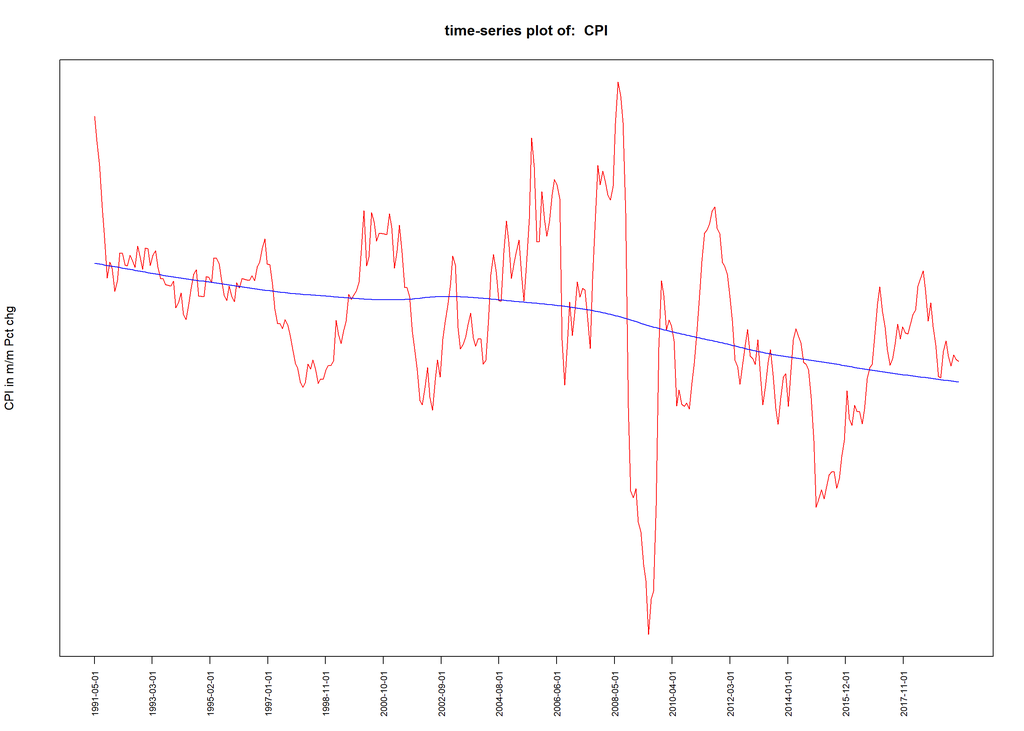

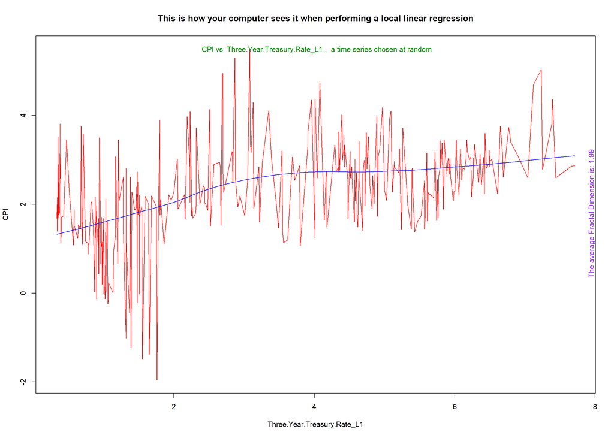

In order to prepare for the genetic algorithm, I removed the last 2 rows of xx and the last 2 elements of the response and stored those as xx.test and response.test respectively.

## Terminology:

#### in this data.frame.bayesian.network, or df.bn, we have many primitive measures of interest:

| acrynym | concise description |
| --- | --- |
| “ss” | randomly selected column number from xx |
| “totalRock” | measure of network connectivity |
| “response.cor” | correlation between the response and all other predictor nodes. |
| “fwd.error1” | out.of.sample 1 - predicted from the 8 predictor nodes from prior periods in time |
| “fwd.error2” | out.of.sample 2 - predicted from the 8 predictor nodes from prior periods in time |
| ‘forecast’ | the forecast ( see DAG directed acyclic graph ) |

```
##   ss1 ss2 ss3 ss4 ss5 ss6 ss7 ss8 totalRock response.cor fwd.error1 fwd.error2 forecast   bn.score     arcStr parentCount
## 1 164 217 225 334 411 537 543 660        27            2 0.05767080 0.00000082 1.628779 -11309.234  -76.53630           3
## 2  74 122 193 430 483 541 730 788        33            3 0.17723187 0.00001318 1.787223  -8954.974  -83.30996           3
## 3  14  98 102 179 291 372 391 669        22            3 0.25355336 0.00002079 1.936501 -11134.151 -166.81723           3
## 4 148 228 303 328 414 474 498 815        34            4 0.06295742 0.00003074 1.799093  -9796.561  -56.72621           3
## 5   3 159 204 276 439 503 559 852        31            3 0.18474390 0.00004605 1.737917 -10885.489  -34.37892           3
## 6 307 498 535 732 738 746 812 825        37            4 0.03354581 0.00009091 1.804123  -8642.303  -37.08748           3
## 7 226 232 287 340 354 413 621 626        21            3 0.06207662 0.00010291 1.929065 -11129.430 -141.96688           3
## 8 521 558 598 601 697 707 729 731        39            5 0.07656200 0.00010401 1.739463  -8199.412 -123.42668           3
```

here is the best performing random sample of size 8 from the predictive time-series matrix, xx. with the response time-seriesID: CPI ( consumer price index chg % Y/Y ) We select for networks with a high degree of connectivity (as measured by the linear correlation ). In fact, we select for this feature from the outset.

In this article we select networks with both potential for forecasting accuracy and network connectivity ( linear correlation and bayes.network.score and total arcStrength for the response and its parents ). Below is an example selected by the genetic algorithm. Notice the large number of lines radiating from the response and the high inter-connectivity globally.

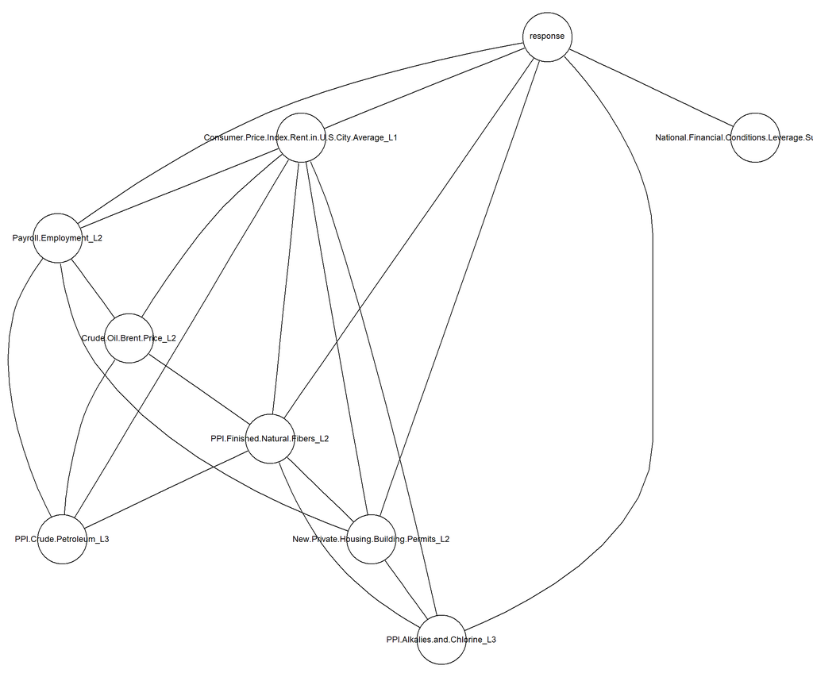

### here is the fittest random sample ( of size 8 ) drawn from xx, the predictive, dynamic data.frame as selected by genetic algorithm.

|  | Consumer.Price.Index.Rent.in.U.S.City.Average_L1 | Payroll.Employment_L2 | Crude.Oil.Brent.Price_L2 | PPI.Finished.Natural.Fibers_L2 | New.Private.Housing.Building.Permits_L2 |
| --- | --- | --- | --- | --- | --- |
| 1991-06-01 | 4.00583 | -1.20432 | 15.45797 | 1.61702 | -19.36620 |
| 1991-07-01 | 3.69833 | -1.44575 | 17.33426 | 0.93458 | -7.12277 |
| 1991-08-01 | 3.60490 | -1.38362 | 20.27664 | 0.50804 | -12.99639 |
| 1991-09-01 | 3.08465 | -1.39496 | 12.97603 | 0.50891 | -9.74026 |
| 1991-10-01 | 3.28571 | -1.18960 | -27.21890 | 1.01954 | -11.69317 |

here are the most frequently occurring leading indicators in the top 1000 models for forecasting CPI ( the response )

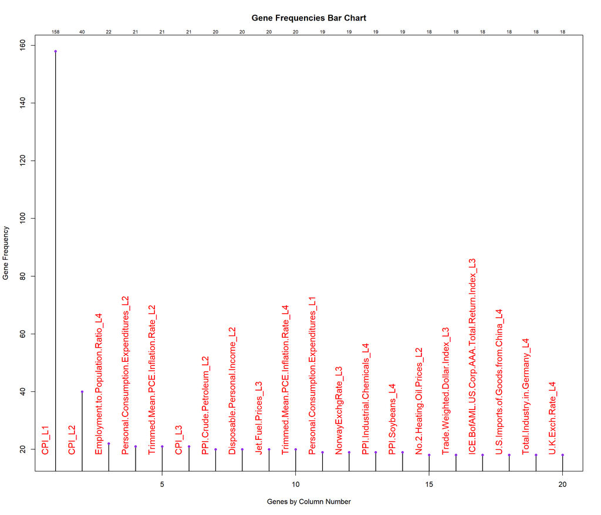

here are the most frequently occurring genes (equivalent terms in review: net.nodes ~ colnames(xx)~ genes in a chromosome )

Most Frequent Genes (nodes) in the fittest bayesian networks

| frequently occurring time series name |
| --- |
| CPI_L1 |
| CPI_L2 |
| Employment.to.Population.Ratio_L4 |
| Personal.Consumption.Expenditures_L2 |
| Trimmed.Mean.PCE.Inflation.Rate_L2 |
| CPI_L3 |
| PPI.Crude.Petroleum_L2 |
| Disposable.Personal.Income_L2 |
| Jet.Fuel.Prices_L3 |
| Trimmed.Mean.PCE.Inflation.Rate_L4 |
| Personal.Consumption.Expenditures_L1 |
| NorwayExchgRate_L3 |
| PPI.Industrial.Chemicals_L4 |
| PPI.Soybeans_L4 |
| No.2.Heating.Oil.Prices_L2 |
| Trade.Weighted.Dollar.Index_L3 |
| ICE.BofAML.US.Corp.AAA.Total.Return.Index_L3 |
| U.S.Imports.of.Goods.from.China_L4 |
| Total.Industry.in.Germany_L4 |

Here is some of the corresponding black list derived from this random sample The black list prevents reverse causation.

black listed arcs to prevent reverse causation

| from | to |
| --- | --- |
| response | Consumer.Price.Index.Rent.in.U.S.City.Average_L1 |
| response | Payroll.Employment_L2 |
| response | Crude.Oil.Brent.Price_L2 |
| response | PPI.Finished.Natural.Fibers_L2 |
| response | New.Private.Housing.Building.Permits_L2 |
| response | PPI.Alkalies.and.Chlorine_L3 |
| response | PPI.Crude.Petroleum_L3 |
| response | National.Financial.Conditions.Leverage.Subindex_L4 |
| Consumer.Price.Index.Rent.in.U.S.City.Average_L1 | Payroll.Employment_L2 |
| Consumer.Price.Index.Rent.in.U.S.City.Average_L1 | Crude.Oil.Brent.Price_L2 |
| Consumer.Price.Index.Rent.in.U.S.City.Average_L1 | PPI.Finished.Natural.Fibers_L2 |
| Consumer.Price.Index.Rent.in.U.S.City.Average_L1 | New.Private.Housing.Building.Permits_L2 |
| Consumer.Price.Index.Rent.in.U.S.City.Average_L1 | PPI.Alkalies.and.Chlorine_L3 |
| Consumer.Price.Index.Rent.in.U.S.City.Average_L1 | PPI.Crude.Petroleum_L3 |
| Consumer.Price.Index.Rent.in.U.S.City.Average_L1 | National.Financial.Conditions.Leverage.Subindex_L4 |
| Payroll.Employment_L2 | Crude.Oil.Brent.Price_L2 |

### here is a panel of dynamic bayesian networks focused on the forecast for:

** Consumer Price Index %chg Y/Y **

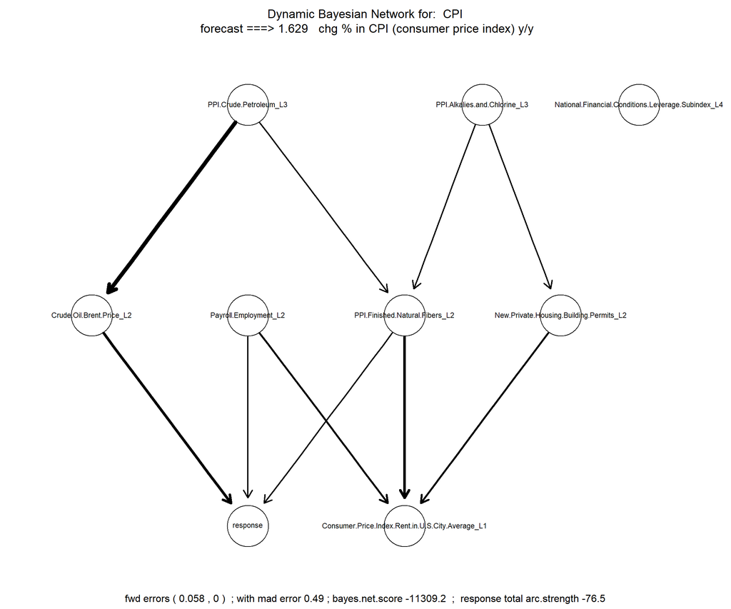

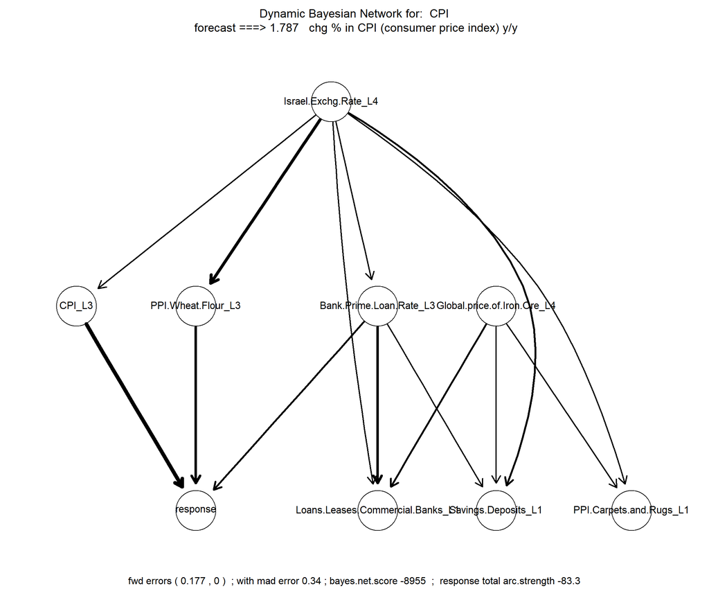

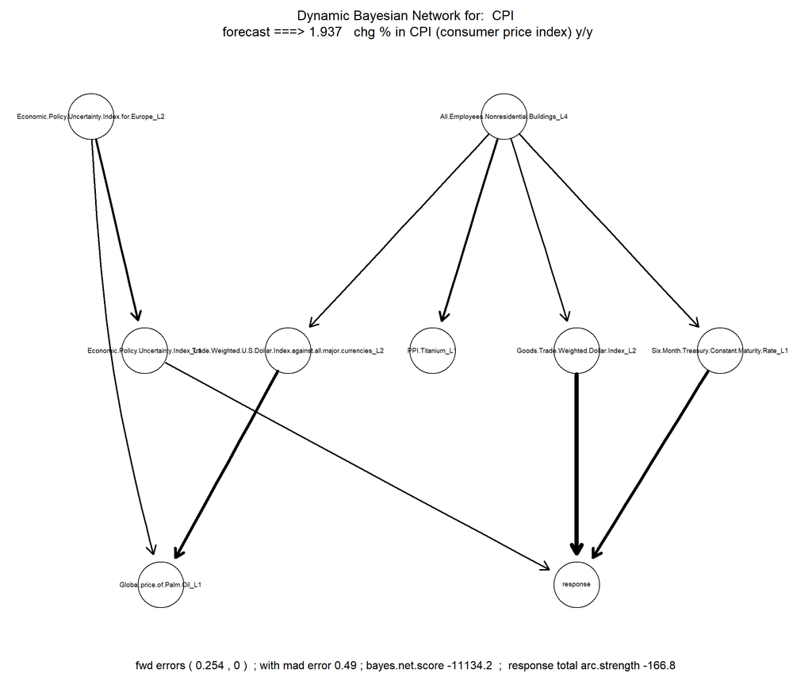

```
## [1] "median forecast:  1.78722257399321"
```